# Homework 1 (Fatos estilizados)

Marcelo Santos Carielo

jul/2023

## Questão 1

*Você deve escolher 4 (quatro) variáveis disponı́veis no Yahoo Finance e verificar os fatos estilizados de séries temporais financeiras, seguindo aproximadamente o que foi mostrado na aula.*

### Fatos Estilizados

#### Séries Temporais Financeiras: Fatos estilizados

- caudas pesadas: retornos de ativos são leptocúrticos (Mandelbrot, 1963; Fama (1963, 1965), ou seja, possuem caudas pesadas - coeficiente de curtose maior que 3. Lembrando que o valor de referência 3 é o que resulta da distribuição Normal. Dessa forma, seria mais apropriado usar distribuições com caudas pesadas para modelagem do retorno de ativos, tais como Pareto-Lévy, t-Student, entre outras.
- efeitos de alavancagem: Black (1976) observou que os movimentos de preço são negativamente correlacionados com a volatilidade. Se há queda nos preços da empresa, ocorre um aumento da alavancagem (endividamento/valor ativo total) e aumento da incerteza o que tende a gerar aumento da volatilidade.
- efeito calendário: retorno/volatilidade variam com o calendário. Exemplo: efeito dia da semana (maior retorno às segundas, etc), proximidade de feriados, intradiários.
- ausência de correlação linear: retornos não autocorrelacionados. Em geral, a série de retornos é estacionária, com média ao redor de zero. Ajustar um modelo ARMA é desafiador e o melhor que poderemos fazer, muitas vezes, é um AR(1).
- quadrados dos retornos são autocorrelacionados: heterocedasticidade condicional. Séries temporais financeiras revelam instantes de tempo de alta e baixa volatilidade que se agrupam (clusters de volatilidade). De fato, agrupamentos de volatilidade e caudas pesadas estão relacionados.
- co-movimentos de volatilidade: globalização dos mercados aumenta a volatilidade e co-movimentos. Contágio.
- efeito de bad news: mercado fica mais “nervoso” com más notícias (bad news) do que com boas notícias (good news).

**fonte:** Slides Aula

## Resposta 1:

Inicialmente, fazemos o download de 4 variáveis do `Yahoo Finance` (https://finance.yahoo.com/, https://br.financas.yahoo.com/world-indices/) utilizando o pacote `BatchGetSymbols` (https://www.rdocumentation.org/packages/BatchGetSymbols/versions/2.6.4/topics/BatchGetSymbols).

**OBS:** Iremos considerar o seguinte período para análise: de `01/jan/2019` a `01/jul/2023`. Além disso, para simplificar, assumiremos que a expressão `retorno` se refere tanto ao `retorno do preço diário (taxa de mundança)` como ao `log` (logaritmo natural) desse valor.

**Referências:** - https://www.b3.com.br/pt_br/produtos-e-servicos/negociacao/renda-variavel/empresas-listadas.htm (Consulta de empresas listadas na B3) - https://br.financas.yahoo.com/quote/%5EBVSP/components/ (30 principais componentes da Ibovespa, principal indicador de desempenho das ações negociadas na B3)

```r
library(BatchGetSymbols, quietly=TRUE)
# ?BatchGetSymbols
# install.packages("BatchGetSymbols", dependencies=TRUE)
# https://stackoverflow.com/questions/31008877/unable-to-install-rvest-package

# define data
date_init <- "2019-01-01"
# date_end <- Sys.Date()
date_end <- "2023-07-01"

# download de dados de ativos no Yahoo Finance
tickers <- c("PETR3.SA", "VALE3.SA", "JBSS3.SA", "PETR4.SA")
assets <- BatchGetSymbols(tickers = tickers,
                          first.date = date_init,
                          last.date = date_end,
                          type.return = "log", # log retorno
                          freq.data = "daily")

# head(assets)

print(assets$df.control$ticker)
```

```
## [1] "PETR3.SA" "VALE3.SA" "JBSS3.SA" "PETR4.SA"
```

```r
glimpse(assets)
```

```
## List of 2
##  $ df.control: tibble [4 × 6] (S3: tbl_df/tbl/data.frame)
##   ..$ ticker              : chr [1:4] "PETR3.SA" "VALE3.SA" "JBSS3.SA" "PETR4.SA"
##   ..$ src                 : chr [1:4] "yahoo" "yahoo" "yahoo" "yahoo"
##   ..$ download.status     : chr [1:4] "OK" "OK" "OK" "OK"
##   ..$ total.obs           : int [1:4] 1117 1117 1117 1117
##   ..$ perc.benchmark.dates: num [1:4] 0.962 0.962 0.962 0.962
##   ..$ threshold.decision  : chr [1:4] "KEEP" "KEEP" "KEEP" "KEEP"
##  $ df.tickers:'data.frame':  4468 obs. of  10 variables:
##   ..$ price.open         : num [1:4468] 25.4 26.6 27.2 27.6 28.6 ...
##   ..$ price.high         : num [1:4468] 27 27.4 27.6 29.1 28.8 ...
##   ..$ price.low          : num [1:4468] 25.1 26.3 27.1 27.5 28.1 ...
##   ..$ price.close        : num [1:4468] 26.6 27.2 27.5 28.4 28.2 ...
##   ..$ volume             : num [1:4468] 14725300 12766200 10848500 16164400 12562900 ...
##   ..$ price.adjusted     : num [1:4468] 10.4 10.6 10.7 11.1 11 ...
##   ..$ ref.date           : Date[1:4468], format: "2019-01-02" "2019-01-03" ...
##   ..$ ticker             : chr [1:4468] "PETR3.SA" "PETR3.SA" "PETR3.SA" "PETR3.SA" ...
##   ..$ ret.adjusted.prices: num [1:4468] NA 0.0204 0.0113 0.0318 -0.0053 ...
##   ..$ ret.closing.prices : num [1:4468] NA 0.0204 0.0113 0.0318 -0.0053 ...
```

```r
assets <- assets[[2]]
```

#### Análise preliminar

A seguir iremos gerar alguns gráficos, para cada um dos 4 ativos escolhidos no Yahoo Finance, de forma que possamos verificar alguns fatos estilizados de séries temporais financeiras.

**Sobre a númeração dos tickers:**

As `ações` são negociadas na bolsa de valores por um código de letras e números - o ticker. As quatro letras maiúsculas representam o nome do ativo. Já os números vão de 1 a 10 e representam, normalmente, o `tipo de ativo`:

. 1: ativo com direito de subscrição a uma Ação ordinária;

. 2: ativo com direito de subscrição a uma Ação preferencial;

. 3: Ação ordinária;

. 4: Ação preferencial;

. 5 a 8: Ações preferenciais das classes A a D;

. 9: subscrição de Ação ordinária;

. 10: subscrição de Ação preferencial.

As `ações ordinárias`, por ex. PETR3 (PETROBRAS) ou JBSS3 (JBS), são as mais comuns no mercado e garantem ao investidor o direito a voto nas assembleias deliberativas. Logo, permitem a participação na tomada de decisões, como escolha dos diretores, alterações no estatuto, etc.

As `ações preferenciais`, como a PETR4, garantem aos investidores a preferência no pagamento de dividendos e outras compensações. O mesmo acontece em caso de falência da companhia. Entretanto, normalmente não há direito a votos na assembleia, nem há a segurança do [Tag Along](https://pt.wikipedia.org/wiki/Tag_along). Outro ponto é que esses papéis são considerados `exigíveis`. Isso significa, basicamente, que a empresa pode solicitar as ações a qualquer momento.

**Fonte:** https://blog.genialinvestimentos.com.br/diferenca-entre-petr3-petr4/

### PETR3 e PETR4 (PETRÓLEO BRASILEIRO S.A.- PETROBRAS)

**Descrição:** Petróleo Brasileiro S.A. (Petrobras) é uma empresa de capital aberto (sociedade anônima), cujo acionista majoritário é o Governo do Brasil (União), sendo, portanto, uma empresa estatal de economia mista. Com sede no Rio de Janeiro, opera atualmente em 14 países, no segmento de energia, prioritariamente nas áreas de exploração, produção, refino, comercialização e transporte de petróleo, gás natural e seus derivados. O seu lema atual é “Uma empresa integrada de energia que atua com responsabilidade social e ambiental”. Em 2020 Forbes Global 2000, a Petrobras foi classificada como a septuagésima maior empresa pública do mundo.

**Fonte:** https://pt.wikipedia.org/wiki/Petrobras

### VALE3 (VALE S.A.)

**Descrição:** Vale S.A. é uma mineradora multinacional brasileira e uma das maiores operadoras de logística do país. É uma das maiores empresas de mineração do mundo e também a maior produtora de minério de ferro, de pelotas e de níquel. A empresa também produz manganês, ferroliga, cobre, bauxita, potássio, caulim, alumina e alumínio. No setor de energia elétrica, a empresa participa em consórcios e atualmente opera nove usinas hidrelétricas, no Brasil, no Canadá e na Indonésia. Em 2008, a empresa chegou a ser a 33° maior do mundo (de acordo com o Financial Times de 2008) e a maior do Brasil em volume de exportações. Em 2009, a marca e o nome de fantasia da empresa deixaram de ser Companhia Vale do Rio Doce (CVRD) e passaram a ser apenas Vale S.A., nome pelo qual sempre foi conhecida nas bolsas de valores.

**Fonte:** https://pt.wikipedia.org/wiki/Vale_S.A.

### JBSS3 (JBS S.A.)

**Descrição:** JBS S.A. (B3: JBSS3) é uma empresa brasileira do setor de alimentosfundada em 1953 em Goiás. A companhia opera no processamento de carnes bovina, suína, ovina, de frango, de peixe e *plant-based*, além de atuar no processamento de couros. Além disso, comercializa produtos de higiene e limpeza, colágeno, embalagens metálicas, biodiesel, entre outros, sendo uma das maiores indústrias de alimentos do mundo. Suas principais operações incluem as marcas Seara, Swift e Friboi.

**Fonte:** https://pt.wikipedia.org/wiki/JBS

```r
library(ggplot2)
library(gridExtra)
min(assets$ref.date)
```

```
## [1] "2019-01-02"
```

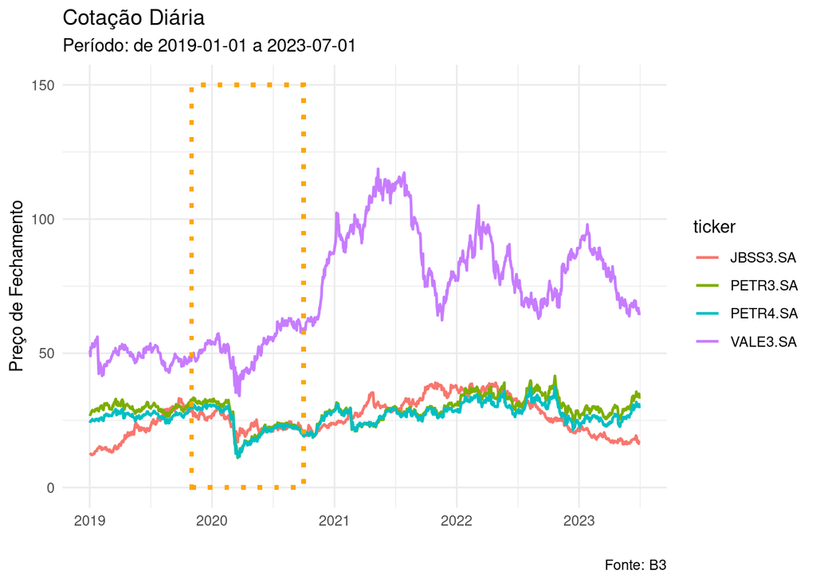

```r
# preço diário
g <- ggplot(data=assets) +
  geom_line(mapping=aes(x=ref.date, y=price.close, color=ticker),
            linewidth=0.8, na.rm=TRUE) +
  geom_rect(aes(xmin=as.Date("2019-11-01"), xmax=as.Date("2020-10-01"),
                ymin=0, ymax=150),
            fill="transparent", linetype=3, color="orange", size=1.2) +
  labs(x="", y="Preço de Fechamento",
       title="Cotação Diária",
       subtitle=paste("Período: de ", date_init, " a ", date_end, sep=""),
       caption="Fonte: B3") +
  theme_minimal()
g
```

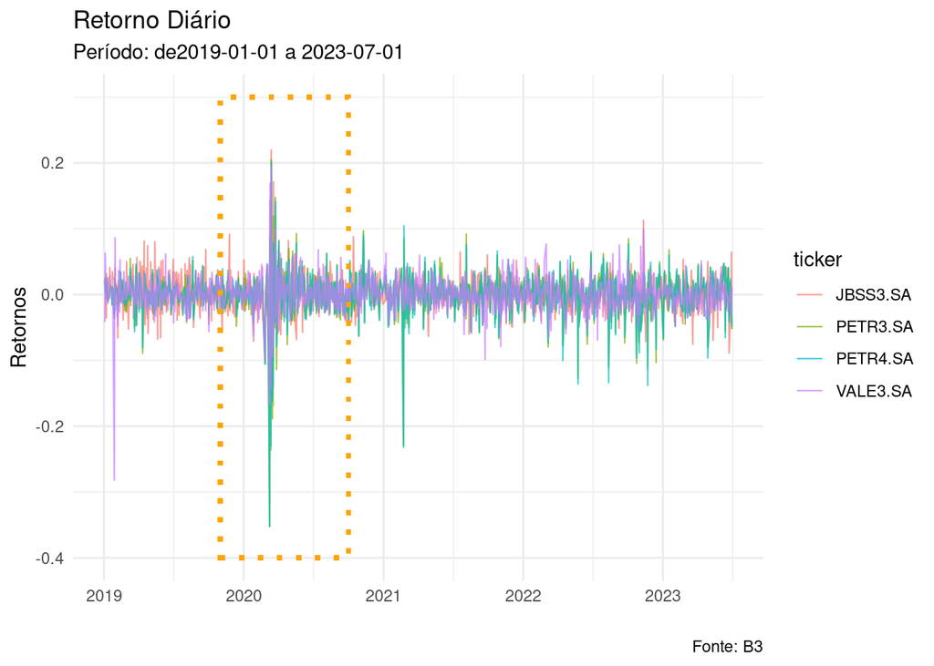

```r
# retorno diário
g.returns <- ggplot(data=assets) +
  geom_line(aes(x=ref.date, y=ret.closing.prices, color=ticker),
            alpha=0.7, linewidth=0.4, na.rm=TRUE) +
  geom_rect(aes(xmin=as.Date("2019-11-01"), xmax=as.Date("2020-10-01"),
                ymin=-0.4, ymax=0.3),
            fill="transparent", linetype=3, color="orange", size=1.2) +
  labs(x="" , y="Retornos",
       title="Retorno Diário",
        subtitle=paste("Período: de", date_init, " a ", date_end, sep=""),
        caption="Fonte: B3") +
    theme_minimal()
g.returns
```

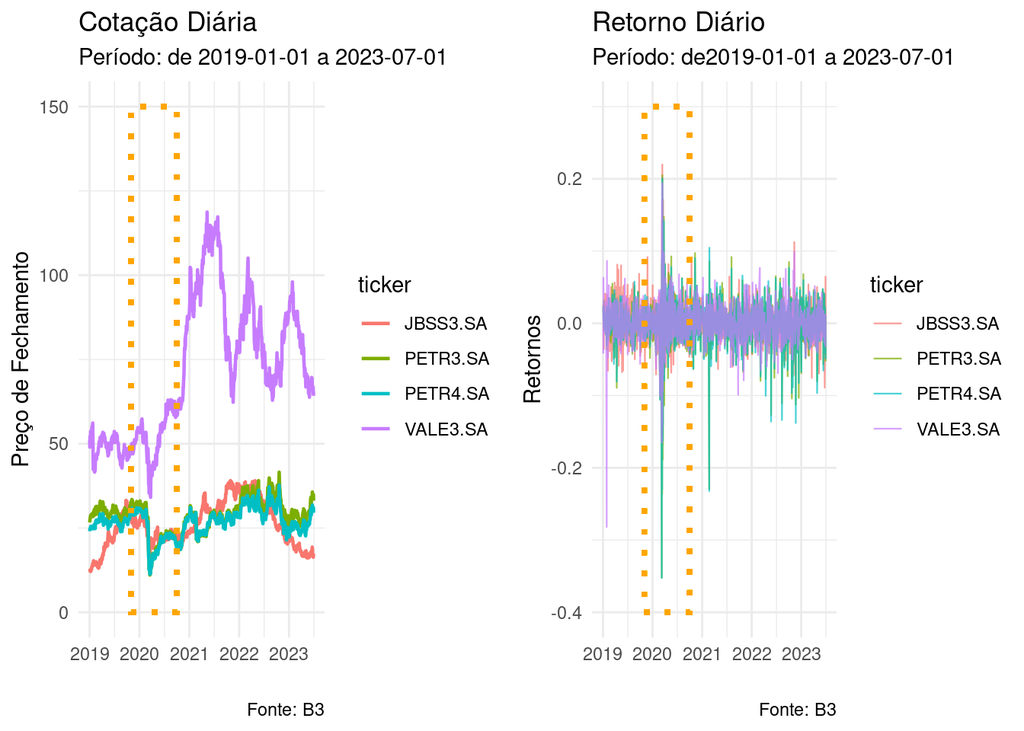

```r
grid.arrange(g, g.returns, nrow=1, ncol=2)
```

Pelos gráficos acima, notamos que a média dos retornos oscila em torno de 0. Além disso, a cotação diária e os retornos possuem o efeito da alavancagem, pois por volta do primeiro semestre de 2020 o preço dos ativos caiu bruscamente (vide gráfico da Cotaçõ Diária, o trecho em destaque). O gráfico de retornos mostra que no mesmo período a volatilidade aumentou e há uma correlação negativa entre os retornos e os preços. De fato, foi neste período que a pandemia de COVID-19 (uma *bad news*) começou a crescer no Brasil, período de muitas incertezas em todos os setores.